# House Prices: EDA and Regression

## Snippets Go to TOC

```python
def eda_numerical_feat(series, title="", with_label=True, number_format=""):
    f, (ax1, ax2) = plt.subplots(ncols=2, figsize=(18, 5), sharex=False)
    print(series.describe())
    if(title != ""):
        f.suptitle(title, fontsize=18)
    sns.distplot(series, ax=ax1)
    sns.boxplot(series, ax=ax2)
    if(with_label):
        describe = series.describe()
        labels = { 'min': describe.loc['min'], 'max': describe.loc['max'],
              'Q1': describe.loc['25%'], 'Q2': describe.loc['50%'],
              'Q3': describe.loc['75%']}
        if(number_format != ""):
            for k, v in labels.items():
                height = 0.3
                if(k == 'Q2'):
                    height = -0.3
                ax2.text(v, height, k + "\n" + number_format.format(v), ha='center', va='center', fontweight='bold',
                         size=12, color='white', bbox=dict(facecolor='#445A64'))
        else:
            for k, v in labels.items():
                ax2.text(v, 0.3, k + "\n" + str(v), ha='center', va='center', fontweight='bold',
                     size=8, color='white', bbox=dict(facecolor='#445A64'))
    plt.show()
```

```python
def plot_top_rank_correlation(my_df, column_target, top_rank=5):
    corr_matrix = my_df.corr()
    f, (ax1, ax2) = plt.subplots(ncols=2, figsize=(18, 6), sharex=False)

    ax1.set_title('Top {} Positive Corr to {}'.format(top_rank, column_target))
    ax2.set_title('Top {} Negative Corr to {}'.format(top_rank, column_target))

    cols_top = corr_matrix.nlargest(top_rank+1, column_target)[column_target].index
    cm = np.corrcoef(my_df[cols_top].values.T)
    mask = np.zeros_like(cm)
    mask[np.triu_indices_from(mask)] = True
    hm = sns.heatmap(cm, cbar=True, annot=True, square=True, fmt='.2f',
                     annot_kws={'size': 8}, yticklabels=cols_top.values,
                     xticklabels=cols_top.values, mask=mask, ax=ax1)

    cols_bot = corr_matrix.nsmallest(top_rank, column_target)[column_target].index
    cols_bot  = cols_bot.insert(0, column_target)
    cm = np.corrcoef(my_df[cols_bot].values.T)
    mask = np.zeros_like(cm)
    mask[np.triu_indices_from(mask)] = True
    hm = sns.heatmap(cm, cbar=True, annot=True, square=True, fmt='.2f',
                     annot_kws={'size': 8}, yticklabels=cols_bot.values,
                     xticklabels=cols_bot.values, mask=mask, ax=ax2)

    plt.show()
```

```python
def test_normal_distribution(serie, series_name='series', thershold=0.4):
    f, (ax1, ax2) = plt.subplots(ncols=2, figsize=(18, 6), sharex=False)
    f.suptitle('{} is a Normal Distribution?'.format(series_name), fontsize=18)
    ax1.set_title("Histogram to " + series_name)
    ax2.set_title("Q-Q-Plot to "+ series_name)

    # calculate normal distrib. to series
    mu, sigma = norm.fit(serie)
    print('Normal dist. (mu= {:,.2f} and sigma= {:,.2f} )'.format(mu, sigma))

    # skewness and kurtoise
    skewness = serie.skew()
    kurtoise = serie.kurt()
    print("Skewness: {:,.2f} | Kurtosis: {:,.2f}".format(skewness, kurtoise))
    # evaluate skeness
    # If skewness is less than −1 or greater than +1, the distribution is highly skewed.
    # If skewness is between −1 and −½ or between +½ and +1, the distribution is moderately skewed.
    # If skewness is between −½ and +½, the distribution is approximately symmetric.
    pre_text = '\t=> '
    if(skewness < 0):
        text = pre_text + 'negatively skewed or left-skewed'
    else:
        text =  pre_text + 'positively skewed or right-skewed\n'
        text += pre_text + 'in case of positive skewness, log transformations usually works well.\n'
        text += pre_text + 'np.log(), np.log1(), boxcox1p()'
    if(skewness < -1 or skewness > 1):
        print("Evaluate skewness: highly skewed")
        print(text)
    if( (skewness <= -0.5 and skewness > -1) or (skewness >= 0.5 and skewness < 1)):
        print("Evaluate skewness: moderately skewed")
        print(text)
    if(skewness >= -0.5 and skewness <= 0.5):
        print('Evaluate skewness: approximately symmetric')
    # evaluate kurtoise
    #     Mesokurtic (Kurtoise next 3): This distribution has kurtosis statistic similar to that of the normal distribution.
    #         It means that the extreme values of the distribution are similar to that of a normal distribution characteristic.
    #         This definition is used so that the standard normal distribution has a kurtosis of three.
    #     Leptokurtic (Kurtosis > 3): Distribution is longer, tails are fatter.
    #         Peak is higher and sharper than Mesokurtic, which means that data are heavy-tailed or profusion of outliers.
    #         Outliers stretch the horizontal axis of the histogram graph, which makes the bulk of the data appear in a
    #         narrow (“skinny”) vertical range, thereby giving the “skinniness” of a leptokurtic distribution.
    #     Platykurtic: (Kurtosis < 3): Distribution is shorter, tails are thinner than the normal distribution. The peak
    #         is lower and broader than Mesokurtic, which means that data are light-tailed or lack of outliers.
    #         The reason for this is because the extreme values are less than that of the normal distribution.
    print('evaluate kurtoise')
    if(kurtoise > 3 + thershold):
        print(pre_text + 'Leptokurtic: anormal: Peak is higher')
    elif(kurtoise < 3 - thershold):
        print(pre_text + 'Platykurtic: anormal: The peak is lower')
    else:
        print(pre_text + 'Mesokurtic: normal: the peack is normal')

    # shapiro-wilki test normality
    # If the P-Value of the Shapiro Wilk Test is larger than 0.05, we assume a normal distribution
    # If the P-Value of the Shapiro Wilk Test is smaller than 0.05, we do not assume a normal distribution
    #     print("Shapiro-Wiki Test: Is Normal Distribution? {}".format(stats.shapiro(serie)[1] < 0.01) )
    #     print(stats.shapiro(serie))


    # ax1 = histogram
    sns.distplot(serie , fit=norm, ax=ax1)
    ax1.legend(['Normal dist. ($\mu=$ {:,.2f} and $\sigma=$ {:,.2f} )'.format(mu, sigma)],
            loc='best')
    ax1.set_ylabel('Frequency')
    # ax2 = qq-plot
    stats.probplot(df_train['SalePrice'], plot=ax2)
    plt.show()
```

```python
def plot_model_score_regression(models_name_list, model_score_list, title=''):
    fig = plt.figure(figsize=(15, 6))
    ax = sns.pointplot( x = models_name_list, y = model_score_list,
        markers=['o'], linestyles=['-'])
    for i, score in enumerate(model_score_list):
        ax.text(i, score + 0.002, '{:.6f}'.format(score),
                horizontalalignment='left', size='large',
                color='black', weight='semibold')
    plt.ylabel('Score', size=20, labelpad=12)
    plt.xlabel('Model', size=20, labelpad=12)
    plt.tick_params(axis='x', labelsize=12)
    plt.tick_params(axis='y', labelsize=12)

    plt.title(title, size=20)

    plt.show()
```

## EDA on 'SalePrice': the target to be predicted Go to TOC

### Top Correlation with 'SalePrice' Go to TOC

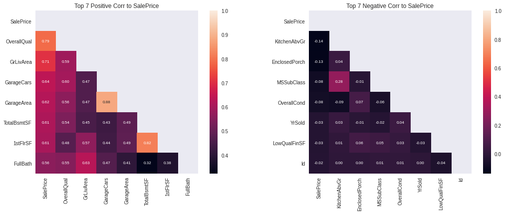

```python
plot_top_rank_correlation(df_train, 'SalePrice', 7)
```

OverallQual and GrLivArea tem as maiores correlações, depois GarageCars e GarageArea

### Outiliers to 'SalePrice' to top corr features Go to TOC

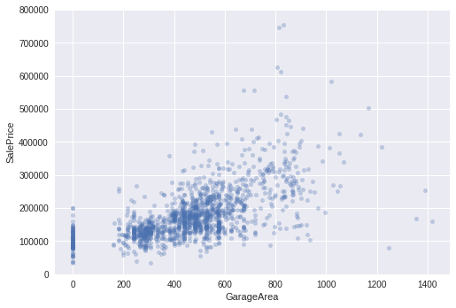

```python
data = pd.concat([df_train['SalePrice'], df_train['GarageArea']], axis=1)
data.plot.scatter(x='GarageArea', y='SalePrice', alpha=0.3, ylim=(0,800000));
```

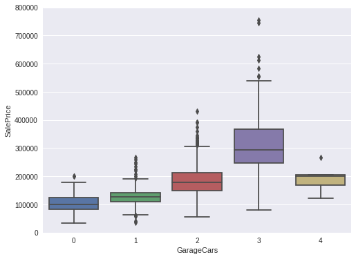

```python
data = pd.concat([df_train['SalePrice'], df_train['GarageCars']], axis=1)
f, ax = plt.subplots(figsize=(8, 6))
fig = sns.boxplot(x=df_train['GarageCars'], y="SalePrice", data=data)
fig.axis(ymin=0, ymax=800000);
```

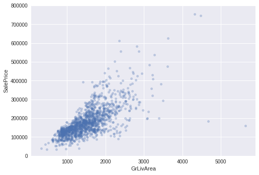

```python
data = pd.concat([df_train['SalePrice'], df_train['GrLivArea']], axis=1)
data.plot.scatter(x='GrLivArea', y='SalePrice', alpha=0.3, ylim=(0,800000));
```

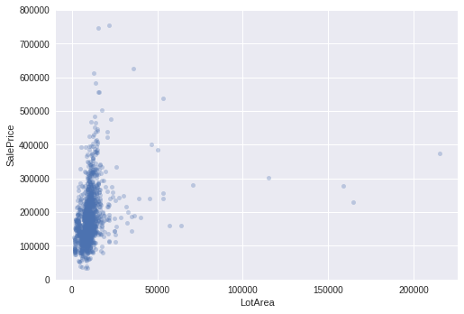

```python
data = pd.concat([df_train['SalePrice'], df_train['LotArea']], axis=1)
data.plot.scatter(x='LotArea', y='SalePrice', alpha=0.3, ylim=(0,800000));
```

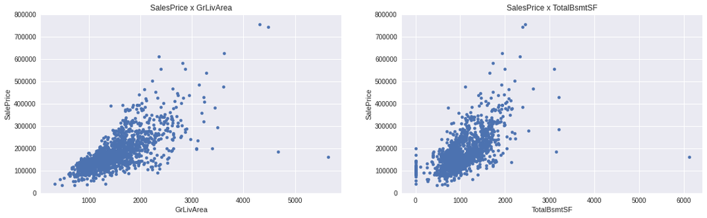

```python
f, (ax1, ax2) = plt.subplots(ncols=2, figsize=(18, 5), sharex=False)


var = 'GrLivArea'
data = pd.concat([df_train['SalePrice'], df_train[var]], axis=1)
data.plot.scatter(x=var, y='SalePrice', ylim=(0,800000), ax=ax1);
ax1.set_title('SalesPrice x GrLivArea')

#scatter plot totalbsmtsf/saleprice
var = 'TotalBsmtSF'
data = pd.concat([df_train['SalePrice'], df_train[var]], axis=1)
data.plot.scatter(x=var, y='SalePrice', ylim=(0,800000), ax=ax2);
ax2.set_title('SalesPrice x TotalBsmtSF')
```

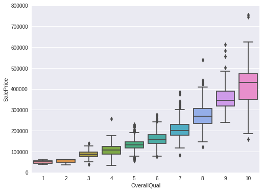

```python
#box plot overallqual/saleprice
var = 'OverallQual'
data = pd.concat([df_train['SalePrice'], df_train[var]], axis=1)
f, ax = plt.subplots(figsize=(8, 6))
fig = sns.boxplot(x=var, y="SalePrice", data=data)
fig.axis(ymin=0, ymax=800000);
```

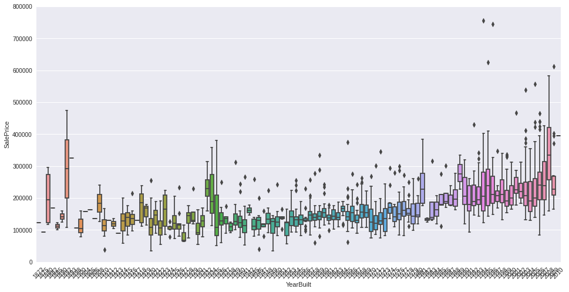

```python
data = pd.concat([df_train['SalePrice'], df_train['YearBuilt']], axis=1)
f, ax = plt.subplots(figsize=(16, 8))
fig = sns.boxplot(x=df_train['YearBuilt'], y="SalePrice", data=data)
fig.axis(ymin=0, ymax=800000);
plt.xticks(rotation=45);
```

consideraçoes

```python
print(df_train.shape[0])
```

```
1460
```

### Remove Outiliers Go to TOC

```python
rows_before = df_train.shape[0]
# Remove outliers
df_train.drop(df_train[(df_train['OverallQual']<5) & (df_train['SalePrice']>200000)].index, inplace=True)
df_train.drop(df_train[(df_train['GrLivArea']>4500) & (df_train['SalePrice']<300000)].index, inplace=True)
# eu adicinei, pois nao segue a reta  normal
df_train.drop(df_train[(df_train['LotArea']>100000)].index, inplace=True)
df_train.reset_index(drop=True, inplace=True)
rows_after = df_train.shape[0]
print("Qtd Row removed outiliers:", rows_before - df_train.shape[0])
```

```
Qtd Row removed outiliers: 7
```

### See 'SalePrice' as normal distribution Go to TOC

```
count     1,453.000
mean    180,565.207
std      79,329.896
min      34,900.000
25%     129,900.000
50%     162,900.000
75%     213,500.000
max     755,000.000
Name: SalePrice, dtype: float64
```

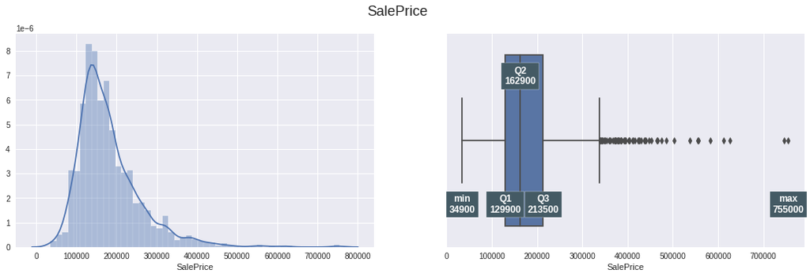

```python
eda_numerical_feat(df_train['SalePrice'], "SalePrice", number_format='{:.0f}')

## color subtitulos
```

```
Normal dist. (mu= 180,565.21 and sigma= 79,302.59 )
Skewness: 1.90 | Kurtosis: 6.64
Evaluate skewness: highly skewed
	=> positively skewed or right-skewed
	=> in case of positive skewness, log transformations usually works well.
	=> np.log(), np.log1(), boxcox1p()
evaluate kurtoise
	=> Leptokurtic: anormal: Peak is higher
```

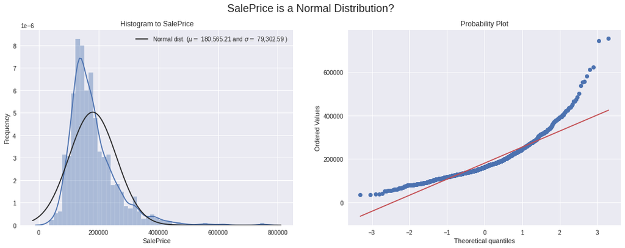

```python
test_normal_distribution(df_train['SalePrice'] , 'SalePrice')
```

### Transform 'SalePrice' in a 'correct' normal distribution Go to TOC

```python
# log(1+x) transform
df_train["SalePrice"] = np.log1p(df_train["SalePrice"])
```

```
Normal dist. (mu= 12.02 and sigma= 0.40 )
Skewness: 0.13 | Kurtosis: 0.83
Evaluate skewness: approximately symmetric
evaluate kurtoise
	=> Platykurtic: anormal: The peak is lower
```

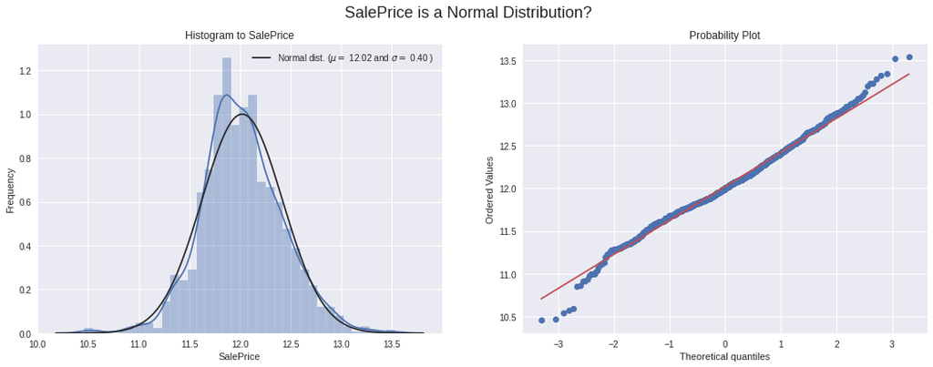

```python
test_normal_distribution(df_train['SalePrice'] , 'SalePrice')
```

## Box Cow to target (A normal Distribution)

http://www.portalaction.com.br/analise-de-capacidade/411-transformacao-de-box-cox

Esse comportamento, posteriormente foi apresentado como a Curva de Gauss. Que mostrava que grande parte dos eventos ficam em torno de um valor médio, com uma certa variabilidade. Você sabe o que é uma curva de distribuição normal? Ou o que essa história que te contei tem haver com isso? Sabe qual a sua importância e para que serve? E como calcular?

Leia mais em: https://www.voitto.com.br/blog/artigo/distribuicao-normal

https://www.voitto.com.br/blog/artigo/distribuicao-normal

## Data Cleaning Go to TOC

### Join Train and Test Datasets to cleaning Go to TOC

```python
# Split features and labels
y_train = df_train['SalePrice'].reset_index(drop=True)
train_features = df_train.drop(['SalePrice'], axis=1)
test_features = df_test

# Combine train and test features in order to apply the feature transformation pipeline to the entire dataset
df_all = pd.concat([train_features, test_features]).reset_index(drop=True)
df_all.shape
```

```
(2912, 80)
```

```python
# ntrain = df_train.shape[0]
# ntest = df_test.shape[0]
# y_train = df_train.SalePrice.values
# df_all = pd.concat((df_train, df_test)).reset_index(drop=True)
# df_all.drop(['SalePrice'], axis=1, inplace=True)
# print("all_data size is : {}".format(df_all.shape))
```

## Missing Data Go to TOC

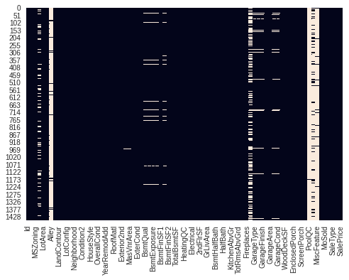

```python
sns.heatmap(df_train.isnull(), cbar=False)
```

```python
def df_rating_missing_data(my_df):
    """Create DataFrame with Missing Rate
    """
    all_data_nan = (my_df.isnull().sum() / len(my_df)) * 100
    all_data_nan = all_data_nan.drop(all_data_nan[all_data_nan == 0].index).sort_values(ascending=False)[:30]
    return pd.DataFrame({'Missing Ratio' :all_data_nan})
```

```python
df_missing_data = df_rating_missing_data(df_train)
df_missing_data
```

|  | Missing Ratio |
| --- | --- |
| PoolQC | 99.587 |
| MiscFeature | 96.421 |
| Alley | 93.737 |
| Fence | 80.661 |
| FireplaceQu | 47.488 |
| LotFrontage | 17.550 |
| GarageYrBlt | 5.575 |
| GarageType | 5.575 |
| GarageFinish | 5.575 |
| GarageQual | 5.575 |
| GarageCond | 5.575 |
| BsmtFinType2 | 2.615 |
| BsmtExposure | 2.615 |
| BsmtFinType1 | 2.546 |
| BsmtCond | 2.546 |
| BsmtQual | 2.546 |
| MasVnrArea | 0.551 |
| MasVnrType | 0.551 |
| Electrical | 0.069 |

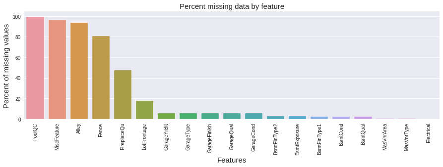

```python
f, ax = plt.subplots(figsize=(15, 4))
plt.xticks(rotation='90')
sns.barplot(x=df_missing_data.index, y=df_missing_data['Missing Ratio'])
plt.xlabel('Features', fontsize=15)
plt.ylabel('Percent of missing values', fontsize=15)
plt.title('Percent missing data by feature', fontsize=15)
```

```python
# Some of the non-numeric predictors are stored as numbers; convert them into strings
df_all['MSSubClass'] = df_all['MSSubClass'].apply(str)
df_all['YrSold'] = df_all['YrSold'].astype(str)
df_all['MoSold'] = df_all['MoSold'].astype(str)
```

```python
# the data description states that NA refers to typical ('Typ') values
df_all['Functional'] = df_all['Functional'].fillna('Typ')
# Replace the missing values in each of the columns below with their mode
df_all['Electrical'] = df_all['Electrical'].fillna("SBrkr")
df_all['KitchenQual'] = df_all['KitchenQual'].fillna("TA")
df_all['Exterior1st'] = df_all['Exterior1st'].fillna(df_all['Exterior1st'].mode()[0])
df_all['Exterior2nd'] = df_all['Exterior2nd'].fillna(df_all['Exterior2nd'].mode()[0])
df_all['SaleType'] = df_all['SaleType'].fillna(df_all['SaleType'].mode()[0])
df_all['MSZoning'] = df_all.groupby('MSSubClass')['MSZoning'].transform(lambda x: x.fillna(x.mode()[0]))

# the data description stats that NA refers to "No Pool"
df_all["PoolQC"] = df_all["PoolQC"].fillna("None")
# Replacing the missing values with 0, since no garage = no cars in garage
for col in ('GarageYrBlt', 'GarageArea', 'GarageCars'):
    df_all[col] = df_all[col].fillna(0)
# Replacing the missing values with None
for col in ['GarageType', 'GarageFinish', 'GarageQual', 'GarageCond']:
    df_all[col] = df_all[col].fillna('None')
# NaN values for these categorical basement df_all, means there's no basement
for col in ('BsmtQual', 'BsmtCond', 'BsmtExposure', 'BsmtFinType1', 'BsmtFinType2'):
    df_all[col] = df_all[col].fillna('None')

# Group the by neighborhoods, and fill in missing value by the median LotFrontage of the neighborhood
df_all['LotFrontage'] = df_all.groupby('Neighborhood')['LotFrontage'].transform(lambda x: x.fillna(x.median()))

# We have no particular intuition around how to fill in the rest of the categorical df_all
# So we replace their missing values with None
objects = []
for i in df_all.columns:
    if df_all[i].dtype == object:
        objects.append(i)
df_all.update(df_all[objects].fillna('None'))

# And we do the same thing for numerical df_all, but this time with 0s
numeric_dtypes = ['int16', 'int32', 'int64', 'float16', 'float32', 'float64']
numeric = []
for i in df_all.columns:
    if df_all[i].dtype in numeric_dtypes:
        numeric.append(i)
df_all.update(df_all[numeric].fillna(0))
```

```python
df_rating_missing_data(df_all)
```

|  | Missing Ratio |
| --- | --- |

### Fix skewness in features to be normal distributions Go to TOC

```python
numeric_dtypes = ['int16', 'int32', 'int64', 'float16', 'float32', 'float64']
numeric = []
for i in df_all.columns:
    if df_all[i].dtype in numeric_dtypes:
        numeric.append(i)
```

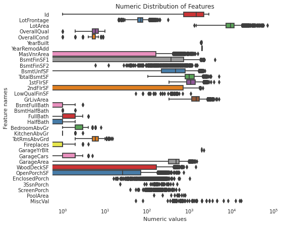

```python
# Create box plots for all numeric features
sns.set_style("white")
f, ax = plt.subplots(figsize=(8, 7))
ax.set_xscale("log")
ax = sns.boxplot(data=df_all[numeric] , orient="h", palette="Set1")
ax.xaxis.grid(False)
ax.set(ylabel="Feature names")
ax.set(xlabel="Numeric values")
ax.set(title="Numeric Distribution of Features")
sns.despine(trim=True, left=True)
```

```python
# Find skewed numerical features
skew_features = df_all[numeric].apply(lambda x: skew(x)).sort_values(ascending=False)

high_skew = skew_features[skew_features > 0.5]
skew_index = high_skew.index

print("There are {} numerical features with Skew > 0.5 :".format(high_skew.shape[0]))
skewness = pd.DataFrame({'Skew' :high_skew})
skew_features.head(10)
```

```
There are 25 numerical features with Skew > 0.5 :
```

```
MiscVal         21.944
PoolArea        17.673
LowQualFinSF    12.074
3SsnPorch       11.362
KitchenAbvGr     4.296
BsmtFinSF2       4.158
EnclosedPorch    3.998
ScreenPorch      3.941
BsmtHalfBath     3.940
LotArea          3.524
dtype: float64
```

```python
# Normalize skewed features
for i in skew_index:
    df_all[i] = boxcox1p(df_all[i], boxcox_normmax(df_all[i] + 1))
```

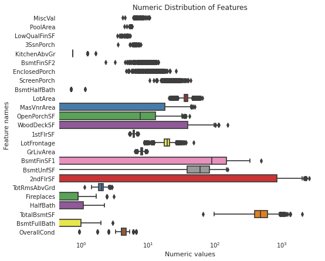

```python
# Let's make sure we handled all the skewed values
sns.set_style("white")
f, ax = plt.subplots(figsize=(8, 7))
ax.set_xscale("log")
ax = sns.boxplot(data=df_all[skew_index] , orient="h", palette="Set1")
ax.xaxis.grid(False)
ax.set(ylabel="Feature names")
ax.set(xlabel="Numeric values")
ax.set(title="Numeric Distribution of Features")
sns.despine(trim=True, left=True)
```

## Feature engineering Go to TOC

### Create New Features Go to TOC

```python
df_all['BsmtFinType1_Unf'] = 1*(df_all['BsmtFinType1'] == 'Unf')
df_all['HasWoodDeck'] = (df_all['WoodDeckSF'] == 0) * 1
df_all['HasOpenPorch'] = (df_all['OpenPorchSF'] == 0) * 1
df_all['HasEnclosedPorch'] = (df_all['EnclosedPorch'] == 0) * 1
df_all['Has3SsnPorch'] = (df_all['3SsnPorch'] == 0) * 1
df_all['HasScreenPorch'] = (df_all['ScreenPorch'] == 0) * 1
df_all['YearsSinceRemodel'] = df_all['YrSold'].astype(int) - df_all['YearRemodAdd'].astype(int)
df_all['Total_Home_Quality'] = df_all['OverallQual'] + df_all['OverallCond']
df_all = df_all.drop(['Utilities', 'Street', 'PoolQC',], axis=1)
df_all['TotalSF'] = df_all['TotalBsmtSF'] + df_all['1stFlrSF'] + df_all['2ndFlrSF']
df_all['YrBltAndRemod'] = df_all['YearBuilt'] + df_all['YearRemodAdd']

df_all['Total_sqr_footage'] = (df_all['BsmtFinSF1'] + df_all['BsmtFinSF2'] +
                                 df_all['1stFlrSF'] + df_all['2ndFlrSF'])
df_all['Total_Bathrooms'] = (df_all['FullBath'] + (0.5 * df_all['HalfBath']) +
                               df_all['BsmtFullBath'] + (0.5 * df_all['BsmtHalfBath']))
df_all['Total_porch_sf'] = (df_all['OpenPorchSF'] + df_all['3SsnPorch'] +
                              df_all['EnclosedPorch'] + df_all['ScreenPorch'] +
                              df_all['WoodDeckSF'])
df_all['TotalBsmtSF'] = df_all['TotalBsmtSF'].apply(lambda x: np.exp(6) if x <= 0.0 else x)
df_all['2ndFlrSF'] = df_all['2ndFlrSF'].apply(lambda x: np.exp(6.5) if x <= 0.0 else x)
df_all['GarageArea'] = df_all['GarageArea'].apply(lambda x: np.exp(6) if x <= 0.0 else x)
df_all['GarageCars'] = df_all['GarageCars'].apply(lambda x: 0 if x <= 0.0 else x)
df_all['LotFrontage'] = df_all['LotFrontage'].apply(lambda x: np.exp(4.2) if x <= 0.0 else x)
df_all['MasVnrArea'] = df_all['MasVnrArea'].apply(lambda x: np.exp(4) if x <= 0.0 else x)
df_all['BsmtFinSF1'] = df_all['BsmtFinSF1'].apply(lambda x: np.exp(6.5) if x <= 0.0 else x)

df_all['haspool'] = df_all['PoolArea'].apply(lambda x: 1 if x > 0 else 0)
df_all['has2ndfloor'] = df_all['2ndFlrSF'].apply(lambda x: 1 if x > 0 else 0)
df_all['hasgarage'] = df_all['GarageArea'].apply(lambda x: 1 if x > 0 else 0)
df_all['hasbsmt'] = df_all['TotalBsmtSF'].apply(lambda x: 1 if x > 0 else 0)
df_all['hasfireplace'] = df_all['Fireplaces'].apply(lambda x: 1 if x > 0 else 0)
```

```python
def logs(res, ls):
    m = res.shape[1]
    for l in ls:
        res = res.assign(newcol=pd.Series(np.log(1.01+res[l])).values)
        res.columns.values[m] = l + '_log'
        m += 1
    return res

log_features = ['LotFrontage','LotArea','MasVnrArea','BsmtFinSF1','BsmtFinSF2','BsmtUnfSF',
                 'TotalBsmtSF','1stFlrSF','2ndFlrSF','LowQualFinSF','GrLivArea',
                 'BsmtFullBath','BsmtHalfBath','FullBath','HalfBath','BedroomAbvGr','KitchenAbvGr',
                 'TotRmsAbvGrd','Fireplaces','GarageCars','GarageArea','WoodDeckSF','OpenPorchSF',
                 'EnclosedPorch','3SsnPorch','ScreenPorch','PoolArea','MiscVal','YearRemodAdd','TotalSF']

df_all = logs(df_all, log_features)
```

```python
def squares(res, ls):
    m = res.shape[1]
    for l in ls:
        res = res.assign(newcol=pd.Series(res[l]*res[l]).values)
        res.columns.values[m] = l + '_sq'
        m += 1
    return res

squared_features = ['YearRemodAdd', 'LotFrontage_log',
              'TotalBsmtSF_log', '1stFlrSF_log', '2ndFlrSF_log', 'GrLivArea_log',
              'GarageCars_log', 'GarageArea_log']
df_all = squares(df_all, squared_features)
```

### Encoded Categorical Features Go to TOC

```python
print('before', df_all.shape)
df_all = pd.get_dummies(df_all).reset_index(drop=True)
print('after encoded categorical features', df_all.shape)
# Remove any duplicated column names
df_all = df_all.loc[:,~df_all.columns.duplicated()]
print('after remove duplicate', df_all.shape)
```

```
before (2912, 133)
after encoded categorical features (2912, 380)
after remove duplicate (2912, 379)
```

## Recreate Train nad Test DataSets Go to TOC

```python
X_train = df_all.iloc[:len(y_train), :]
X_test = df_all.iloc[len(y_train):, :]
X_train.shape, y_train.shape, X_test.shape
```

```
((1453, 379), (1453,), (1459, 379))
```

## Developing models Go to TOC

### Evaluate models with CrossValidation Go to TOC

Cross valaidation serve para avaliar o mdoelo para novos dados.

Diferente de t reinar e testar, queremos saber para o nosso modelo o quao bom ele é pra tetar em outros dados, pois sua estratgia é treinar/testar sobre dados diversos.

Exemplop:

Imagina que você faz um modello e elete tem 90% de acerto no conjutno de teste.

Depois, vocÊ aplica esse modelo em produçâo e tem resultados de 70%.

O que pode ter acontecido?

Talvez para os dados de testse ele se sai muito bem, mas para dados difernetes do de testse saia ruim (Overfittin).

ENtao usamos Cross validation com K-Fold:

- Dividmiso o conjunto de treino em K partes,
- usasmos a maior parte para trieno e uma pequena para tests
- Obtemos resultados avaliandao treinamento e tests variandos ambos.
- Assim fazemos a media e temos mais ideia de quais modelos sâo mais estáveis (vendo o desvio padrao) e quais tem melhores resultados na media (avalaindao a media)

```python
from sklearn.model_selection import GridSearchCV, KFold, cross_val_score, train_test_split
from sklearn.preprocessing import OneHotEncoder, LabelEncoder, StandardScaler, RobustScaler, scale
from sklearn.decomposition import PCA
from sklearn.linear_model import ElasticNet, LassoCV, BayesianRidge, LassoLarsIC
from sklearn.linear_model import Ridge, RidgeCV, ElasticNet, ElasticNetCV
from sklearn.kernel_ridge import KernelRidge
from mlxtend.regressor import StackingCVRegressor
from sklearn.pipeline import make_pipeline
from sklearn.ensemble import RandomForestRegressor, GradientBoostingRegressor
from sklearn.ensemble import AdaBoostRegressor, BaggingRegressor
from sklearn.metrics import mean_squared_error
from sklearn.base import BaseEstimator, TransformerMixin, RegressorMixin, clone
from sklearn.svm import SVR

from lightgbm import LGBMRegressor
from xgboost import XGBRegressor
```

```python
# Setup cross validation folds
kf = KFold(n_splits=4, random_state=42, shuffle=True)

# Define error metrics
def rmsle(y, y_pred):
    return np.sqrt(mean_squared_error(y, y_pred))

def cv_rmse(model, X=X_train):
    rmse = np.sqrt(-cross_val_score(model, X, y_train, scoring="neg_mean_squared_error", cv=kf))
    return (rmse)
```

```python
# Light Gradient Boosting Regressor
lightgbm = LGBMRegressor(objective='regression',
                       num_leaves=6,
                       learning_rate=0.01,
                       n_estimators=7000,
                       max_bin=200,
                       bagging_fraction=0.8,
                       bagging_freq=4,
                       bagging_seed=8,
                       feature_fraction=0.2,
                       feature_fraction_seed=8,
                       min_sum_hessian_in_leaf = 11,
                       verbose=-1,
                       random_state=42)

# XGBoost Regressor
xgboost = XGBRegressor(learning_rate=0.01,
                       n_estimators=6000,
                       max_depth=4,
                       min_child_weight=0,
                       gamma=0.6,
                       subsample=0.7,
                       colsample_bytree=0.7,
                       objective='reg:squarederror',
                       nthread=-1,
                       scale_pos_weight=1,
                       seed=27,
                       reg_alpha=0.00006,
                       random_state=42)

# Ridge Regressor
ridge_alphas = [1e-15, 1e-10, 1e-8, 9e-4, 7e-4, 5e-4, 3e-4, 1e-4, 1e-3, 5e-2, 1e-2, 0.1, 0.3, 1, 3, 5, 10, 15, 18, 20, 30, 50, 75, 100]
ridge = make_pipeline(RobustScaler(), RidgeCV(alphas=ridge_alphas, cv=kf))

# setup models
lasso_alphas2 = [5e-05, 0.0001, 0.0002, 0.0003, 0.0004, 0.0005, 0.0006, 0.0007, 0.0008]

elastic_alphas = [0.0001, 0.0002, 0.0003, 0.0004, 0.0005, 0.0006, 0.0007]
elastic_l1ratio = [0.8, 0.85, 0.9, 0.95, 0.99, 1]


# Lasso Regressor
lasso = make_pipeline(RobustScaler(),
                      LassoCV(max_iter=1e7, alphas=lasso_alphas2,
                              random_state=42, cv=kf))
# Elastic Net Regressor
elasticnet = make_pipeline(RobustScaler(),
                           ElasticNetCV(max_iter=1e7, alphas=elastic_alphas,
                                        cv=kf, l1_ratio=elastic_l1ratio))

# Kernel Ridge
KRR = KernelRidge(alpha=0.6, kernel='polynomial', degree=2, coef0=2.5)

# Support Vector Regressor
svr = make_pipeline(RobustScaler(), SVR(C= 20, epsilon= 0.008, gamma=0.0003))

# Gradient Boosting Regressor
gbr = GradientBoostingRegressor(n_estimators=6000,
                                learning_rate=0.01,
                                max_depth=4,
                                max_features='sqrt',
                                min_samples_leaf=15,
                                min_samples_split=10,
                                loss='huber',
                                random_state=42)

# Random Forest Regressor
rf = RandomForestRegressor(n_estimators=1200,
                          max_depth=15,
                          min_samples_split=5,
                          min_samples_leaf=5,
                          max_features=None,
                          oob_score=True,
                          random_state=42)

# Stack up all the models above, optimized using xgboost
stack_gen = StackingCVRegressor(regressors = (xgboost, lightgbm, svr, ridge, gbr, rf),
                                meta_regressor = xgboost,
                                use_features_in_secondary=True)
```

```python
regressor_models = {
    'LightGB': lightgbm, # 20s
    'XGBoost': xgboost, # 340s = 5min 40s
    'SVM_Regressor': svr, # 6s
    'Ridge': ridge, # 6s
    'RandomForest': rf, # 146s = 2min 20s
    'GradientBoosting': gbr, # 93s = 1min 30s
    # 'stack_gen': stack_gen, # Nâo tem como fazer, esse CV é para avaliar os outros, nao tem como aplicar o CV ao Stack
    ## ADD++
    'Lasso': lasso, # 15s
    'KernelRidge': KRR, # 1.88s
    'ElasticNet': elasticnet # 40s
}

scores = {}

## Cross Validation
t_start = time.time()

for model_name, model in regressor_models.items():
    print(model_name)
    t0 = time.time()
    score = cv_rmse(model)
    t1 = time.time()
    m, s = score.mean(), score.std()
    scores[model_name] = [m,s]
    print('\t=> mean {:.5f}, std: {:.5f}'.format(m, s))
    print("\t=> took {:,.3f} s".format(t1 - t0))

t_ending = time.time()
print('took', t_ending - t_start)
```

```
LightGB
	=> mean 0.12171, std: 0.00525
	=> took 19.994 s
XGBoost
	=> mean 0.14205, std: 0.00622
	=> took 350.164 s
SVM_Regressor
	=> mean 0.11428, std: 0.00612
	=> took 5.118 s
Ridge
	=> mean 0.11311, std: 0.00469
	=> took 6.300 s
RandomForest
	=> mean 0.14068, std: 0.00587
	=> took 147.834 s
GradientBoosting
	=> mean 0.11569, std: 0.00283
	=> took 104.966 s
Lasso
	=> mean 0.11090, std: 0.00504
	=> took 14.873 s
KernelRidge
	=> mean 0.12917, std: 0.00911
	=> took 2.093 s
ElasticNet
	=> mean 0.11074, std: 0.00498
	=> took 40.203 s
took 691.5493047237396
```

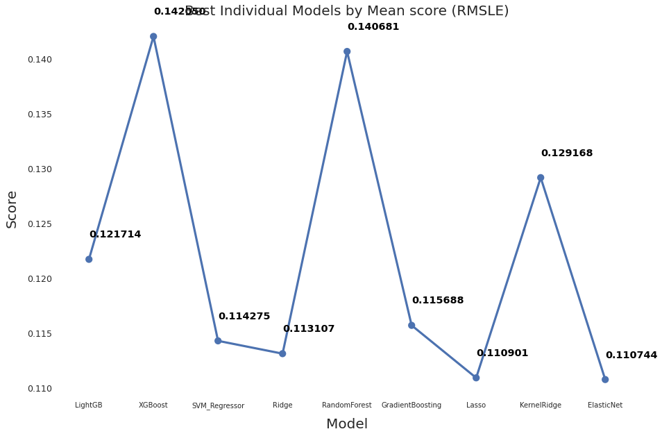

```python
plot_model_score_regression(list(scores.keys()),
                            [score for score, _ in scores.values()],
                            'Best Individual Models by Mean score (RMSLE)')
```

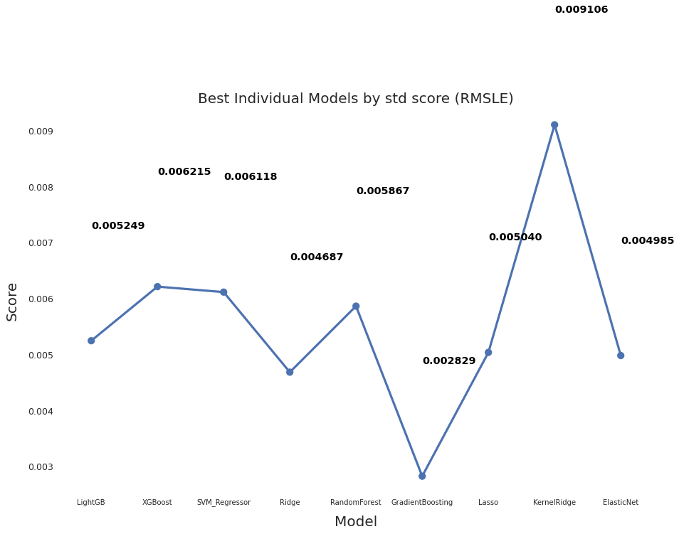

```python
plot_model_score_regression(list(scores.keys()),
                            [score for _, score in scores.values()],
                            'Best Individual Models by std score (RMSLE)')
```